From the [dataset description](https://github.com/rfordatascience/tidytuesday/blob/master/data/2023/2023-08-29/readme.md):

> The data this week comes from the U.S. Copyright Office Fair Use Index.

> > Fair use is a longstanding and vital aspect of American copyright law. The goal of the Index is to make the principles and application of fair use more accessible and understandable to the public by presenting a searchable database of court opinions, including by category and type of use (e.g., music, internet/digitization, parody).

> There are two datasets this week for which the rows align, but the values might not precisely line up for a clean join – a case you often have to deal with in real-world data.

This last point is what I’ll be focusing on in this post: The challenge of joining two datasets together that don’t line up for a clean join.

```r
library(tidyverse)
library(fuzzyjoin)
library(gt)
fair_use_cases <- readr::read_csv('https://raw.githubusercontent.com/rfordatascience/tidytuesday/master/data/2023/2023-08-29/fair_use_cases.csv')
fair_use_findings <- readr::read_csv('https://raw.githubusercontent.com/rfordatascience/tidytuesday/master/data/2023/2023-08-29/fair_use_findings.csv')
```

# Glimpse

```r
glimpse(fair_use_cases)
```

```
## Rows: 251
## Columns: 7
## $ case           <chr> "De Fontbrune v. Wofsy, 39 F.4th 1214 (9th Cir. 2022)",…
## $ year           <dbl> 2022, 2022, 2022, 2022, 2022, 2022, 2022, 2022, 2022, 2…
## $ court          <chr> "9th Circuit", "C.D. Cal.", "S.D.N.Y.", "D.D.C.", "2d C…
## $ jurisdiction   <chr> "9th Circuit", "9th Circuit", "2nd Circuit", "District …
## $ categories     <chr> "Education/Scholarship/Research; Photograph", "Painting…
## $ outcome        <chr> "Fair use not found", "Preliminary finding; Fair use no…
## $ fair_use_found <lgl> FALSE, FALSE, TRUE, FALSE, TRUE, FALSE, FALSE, TRUE, TR…
```

```r
glimpse(fair_use_findings)
```

```
## Rows: 251
## Columns: 9
## $ title       <chr> "De Fontbrune v. Wofsy", "Sedlik v. Von Drachenberg", "Ske…
## $ case_number <chr> "39 F.4th 1214 (9th Cir. 2022)", "No. CV 21-1102, 2022 WL …
## $ year        <chr> "2022", "2022", "2022", "2022", "2022", "2022", "2022", "2…
## $ court       <chr> "United States Court of Appeals for the Ninth Circuit", "U…
## $ key_facts   <chr> "Plaintiffs own the rights to a catalogue comprised of 16,…
## $ issue       <chr> "Whether reproduction of photographs documenting artwork i…
## $ holding     <chr> "The panel held that the first factor, the purpose and cha…
## $ tags        <chr> "Education/Scholarship/Research; Photograph", "Painting/Dr…
## $ outcome     <chr> "Fair use not found", "Preliminary finding; Fair use not f…
```

# Approach 0: column binding

I wonder if a simple `bind_cols()` could work?

```r
fair_use_cases %>%
  arrange(case, year) -> fair_use_sorted
fair_use_findings %>%
  arrange(title, case_number, year) %>%
  select(-year, -outcome, -court) -> fair_use_findings_sorted
fair_use_sorted %>%
  bind_cols(fair_use_findings_sorted) -> bind_cols_join
```

No, as we can see there is some mis-alignment with this approach: `case` and `title` do not match.

```r
bind_cols_join %>%
  select(case, title) %>%
  head(111) %>%
  tail(3) %>%
  gt() %>%
  opt_interactive() %>%
  tab_header(title = "bind_cols() results") %>%
  tab_options(table.background.color = '#f1f3f5',
              ihtml.page_size_default = 3)
```

bind_cols() results

| case | title |
| --- | --- |
| Hosseinzadeh v. Klein, No. 16-CV-3081 (S.D.N.Y. Aug. 23, 2017) | House of Bryant Publ’ns, L.L.C. v. A&E Television Networks, |
| House of Bryant Publ’ns, L.L.C. v. A&E Television Networks, No. 3:09-0502 (M.D. Tenn. Oct. 30, 2009) | Hustler Magazine, Inc. v. Moral Majority, Inc., |
| Hustler Magazine, Inc. v. Moral Majority, Inc., 796 F.2d 1148 (9th Cir. 1986) | In re DMCA Subpoena to Reddit, Inc. |

# Approach 1: Fuzzy joining

I noticed that `title` tends to be a substring of `case`. Given this, I can try “fuzzy matching” I’ll use the `fuzzyjoin` library. I’ll also join with year, just in case there are multiple substring matches this should help to better resolve them to their correct match.

```r
fair_use_cases %>%
  fuzzy_left_join(fair_use_findings %>% select(-court, -outcome),
                  by = c("case" = "title", "year" = "year"),
                  match_fun = str_detect) %>%
  select(-year.y) %>%
  rename(year = year.x) -> fuzzy_join

(fuzzy_join %>%
  filter(is.na(title)) %>%
  distinct(case, title) %>%
  count())$n
```

```
## [1] 37
```

This seems promising: only 37 records did not match. Can I fine-tune it?

I find that it always helps to look at examples of errors and see what can be learned.

```r
## Identify the missing cases from each set
fuzzy_join %>%
  filter(is.na(title)) %>%
  select(colnames(fair_use_cases)) -> cases_without_match

fair_use_findings %>%
  filter(!title %in% fuzzy_join$title) -> findings_without_match

cases_without_match %>%
  select(case, year) %>%
  arrange(case, year) %>%
  gt() %>%
  opt_interactive() %>%
  tab_header(title = "Cases without a match in Findings") %>%
  tab_options(table.background.color = '#f1f3f5',
              ihtml.page_size_default = 3)
```

Cases without a match in Findings

| case | year |
| --- | --- |
| Am. Geophysical Union v. Texaco, Inc., 60 F.3d 913 (2d Cir. 1994) | 1994 |
| Barcroft Media, Ltd. v. Coed Media Group, LLC, No. 16-CV-7634 (JMF) (S.D.N.Y. Nov. 2, 2017) | 2017 |
| Benny v. Loew's, Inc., 239 F.2d 532 (9th Cir. 1956) | 1956 |
| Bouchat v. Balt. Ravens Ltd. P'ship, 619 F.3d 301 (4th Cir. 2010) | 2010 |
| Bouchat v. Balt. Ravens Ltd. P'ship, 737 F.3d 932 (4th Cir. 2013) | 2013 |
| Brownmark Films, L.L.C. v. Comedy Partners, 682 F.3d 687 (7th Cir. 2012) | 2012 |
| CCA and B, LLC v. F + W Media, Inc., 819 F. Supp. 2d 1310 (Ν.D. Ga. 2011) | 2011 |
| Cambridge Univ. Press v. Becker, No. No. 1:08-cv-1425-ODE (N.D. Ga. Mar. 2, 2020) | 2020 |
| Cambridge University Press v. Becker, 1:08-cv-01425-ODE (N.D. Ga. March 31, 2016) | 2016 |
| Castle Rock Entm’t, Inc. v. Carol Publ’g Grp., Inc., 150 F.3d 132 (2d Cir. 1998) | 1998 |

[output cut: 27 more lines]

```r
findings_without_match %>%
  select(title, case_number, year) %>%
  arrange(title, year) %>%
  gt() %>%
  opt_interactive() %>%
  tab_header(title = "Findings without a match in Cases") %>%
  tab_options(table.background.color = '#f1f3f5',
              ihtml.page_size_default = 3)
```

Findings without a match in Cases

| title | case_number | year |
| --- | --- | --- |
| Am. Geophysical Union v. Texaco, Inc., | 60 F.3d 913 (2d Cir. 1995) | 1995 |
| Barcroft Media, Ltd. V. Coed Media Group, LLC | No. 16-CV-7634 (JMF) (S.D.N.Y. Nov. 2, 2017) | 2017 |
| Benny v. Loew's, Inc., | 239 F.2d 532 (9th Cir. 1956), aff’d by an equally divided court, 356 U.S. 43 (1958) | 1958 |
| Bouchat v. Balt. Ravens Ltd. P’ship, | 619 F.3d 301 (4th Cir. 2010) | 2010 |
| Bouchat v. Balt. Ravens Ltd. P’ship, | 737 F.3d 932 (4th Cir. 2013) | 2013 |
| Brownmark Films, LLC v. Comedy Partners, | 682 F.3d 687 (7th Cir. 2012) | 2012 |
| CCA and B, LLC v. F + W Media, Inc., | 819 F. Supp. 2d 1310 (N.D. Ga. 2011) | 2011 |
| Cambridge University Press v. Becker | No. 1:08-cv-1425-ODE, 2020 U.S. Dist. LEXIS 35134 (N.D. Ga. Mar. 2, 2020) | 2020 |
| Cambridge University Press v. Mark P. Becker | No. 1:08-cv-01425-ODE (N.D. Ga. Mar. 31, 2016) appeal docketed, Aug. 26, 2016 | 2016 |
| Castle Rock Entm’t, Inc. v. Carol Publ. Group, Inc., | 150 F.3d 132 (2d Cir. 1998) | 1998 |

[output cut: 26 more lines]

These steps could improve the match rate:

1. Convert to ASCII
2. Convert to lowercase
3. Remove occurrences of `LLC`

I’ll perform these standardizations and try joining again.

# Approach 2: Fuzzy joining + string cleaning

```r
# Mutate a standardized variable: case_std
fair_use_cases %>%
  mutate(case_std = tolower(case),
         case_std = iconv(case_std, to='ASCII//TRANSLIT'),
         case_std = str_replace_all(case_std, "[^[:alnum:][:space:]]", ""),
         case_std = str_replace_all(case_std, 'llc', '')) -> fair_use_cases_std

# Mutate a standardized variable: title_std
fair_use_findings %>%
  mutate(year = str_sub(year, 1, 4),
         title_std = tolower(title),
         title_std = iconv(title_std, to='ASCII//TRANSLIT'),
         title_std = str_replace_all(title_std, "[^[:alnum:][:space:]]", ""),
         title_std = str_replace_all(title_std, 'llc', '')) -> fair_use_findings_std

# Perform a fuzzy join
fair_use_cases_std %>%
  fuzzy_left_join(fair_use_findings_std %>% select(-year, -court, -outcome),
                  by = c("case_std" = "title_std"),
                  match_fun = str_detect) -> fuzzy_join

## Identify the missing cases from each set
fuzzy_join %>%
  filter(is.na(title)) %>%
  select(colnames(fair_use_cases)) -> fair_use_cases_remainder

fair_use_findings_std %>%
  filter(!title %in% fuzzy_join$title) -> fair_use_findings_remainder

fair_use_cases_remainder %>%
  select(case, year) %>%
  arrange(case, year) %>%
  gt() %>%
  opt_interactive() %>%
  tab_header(title = "Cases without a match in Findings") %>%
  tab_options(table.background.color = '#f1f3f5',
              ihtml.page_size_default = 3)
```

Cases without a match in Findings

| case | year |
| --- | --- |
| Cambridge Univ. Press v. Becker, No. No. 1:08-cv-1425-ODE (N.D. Ga. Mar. 2, 2020) | 2020 |
| Castle Rock Entm’t, Inc. v. Carol Publ’g Grp., Inc., 150 F.3d 132 (2d Cir. 1998) | 1998 |
| Consumers Union, Inc. v. Gen. Signal Corp., 724 F.2d 1044 (2d Cir. 1983) | 1983 |
| Dow Jones & Co. v. Brd. of Trade of Chi., 546 F. Supp. 113 (S.D.N.Y. 1982) | 1982 |
| Educ. Testing Servs. v. Katzman, 793 F.2d 533 (3d Cir. 1986) | 1986 |
| Eisenschiml v. Fawcett Publ’ns, Inc., 246 F.2d 598 (7th Cir. 1957) | 1957 |
| Harper & Row Publishers, Inc. v. Nation Enters., 471 U.S. 539 (1985) | 1985 |
| Hosseinzadeh v. Klein, No. 16-CV-3081 (S.D.N.Y. Aug. 23, 2017) | 2017 |
| Metro-Goldwyn-Mayer, Inc. v. Am. Honda Motor Co., 900 F. Supp. 1287 (C.D. Cal. 1995) | 1995 |
| Northland Family Planning Clinic, Inc. v. Crt. for Bio-Ethical Reform, 868 F. Supp. 2d 962 (C.D. Cal. 2012) | 2012 |

[output cut: 6 more lines]

```r
fair_use_findings_remainder %>%
  select(title, case_number, year) %>%
  arrange(title, year) %>%
  gt() %>%
  opt_interactive() %>%
  tab_header(title = "Findings without a match in Cases") %>%
  tab_options(table.background.color = '#f1f3f5',
              ihtml.page_size_default = 3)
```

Findings without a match in Cases

| title | case_number | year |
| --- | --- | --- |
| Cambridge University Press v. Mark P. Becker | No. 1:08-cv-01425-ODE (N.D. Ga. Mar. 31, 2016) appeal docketed, Aug. 26, 2016 | 2016 |
| Castle Rock Entm’t, Inc. v. Carol Publ. Group, Inc., | 150 F.3d 132 (2d Cir. 1998) | 1998 |
| Consumers Union of U.S., Inc. v. Gen. Signal Corp., | 724 F.2d 1044 (2d Cir. 1983) | 1983 |
| Dow Jones & Co., Inc. v. Bd. of Trade of the City of Chi., | 546 F. Supp. 113 (S.D.N.Y. 1982) | 1982 |
| Educ. Testing Serv. v. Katzman, | 793 F.2d 533 (3d Cir. 1986), abrogated on other grounds by eBay, Inc. v. MercExchange, LLC, 547 U.S. 388 (2006) | 1986 |
| Eisenschiml v. Fawcett Publ’n, Inc., | 246 F.2d 598 (7th Cir. 1957) | 1957 |
| Harper & Row Publishers, Inc. v. Nation Enterprises, | 471 U.S. 539 (1985) | 1985 |
| Matt Hosseinzadeh v. Ethan Klein and Hila Klein | No. 16-CV-3081 (S.D.N.Y. Aug. 23, 2017) | 2017 |
| Metro-Goldwyn-Mayer, Inc. v. Am. Honda Motor Co., Inc., | 900 F. Supp. 1287 (C.D. Cal. 1995) | 1995 |
| Northland Family Planning Clinic, Inc. v. Ctr. for Bio-Ethical Reform, | 868 F. Supp. 2d 962 (C.D. Cal. 2012) | 2012 |

[output cut: 6 more lines]

I can see that 16 are missing in each case, and what’s interesting about these two sets is they appear to be the same items, in the same order. This means we can simply do a `bind_cols()` operation to join them together.

# Final solution: Fuzzy joining + string cleaning + column binding

Here I put all of the lessons learned so far in fuzzy joining together into one final chunk of code.

```r
# Mutate a standardized variable: case_std
fair_use_cases %>%
  mutate(case_std = tolower(case),
         case_std = iconv(case_std, to='ASCII//TRANSLIT'),
         case_std = str_replace_all(case_std, "[^[:alnum:][:space:]]", ""),
         case_std = str_replace_all(case_std, 'llc', '')) %>%
  select(-court, -outcome) -> fair_use_cases_std

# Mutate a standardized variable: title_std
fair_use_findings %>%
  mutate(year = str_sub(year, 1, 4),
         title_std = tolower(title),
         title_std = iconv(title_std, to='ASCII//TRANSLIT'),
         title_std = str_replace_all(title_std, "[^[:alnum:][:space:]]", ""),
         title_std = str_replace_all(title_std, 'llc', '')) -> fair_use_findings_std

# Perform a fuzzy join
fair_use_cases_std %>%
  fuzzy_left_join(fair_use_findings_std,
                  by = c("case_std" = "title_std", "year" = "year"),
                  match_fun = str_detect) %>%
  select(-case_std,
         -title_std,
         -year.y) %>%
  rename(year = year.x) -> fuzzy_join

# Identify the missing cases from each set
fuzzy_join %>%
  filter(is.na(title)) %>%
  select(colnames(fair_use_cases)) -> fair_use_cases_remainder

fair_use_findings_std %>%
  select(-year, -court, -outcome) %>%
  filter(!title %in% fuzzy_join$title) -> fair_use_findings_remainder

# Bind the columns together
fair_use_cases_remainder %>%
  select(colnames(fair_use_cases)) %>%
  bind_cols(fair_use_findings_remainder) -> remainders_join

# Join together the two subsets
fuzzy_join %>%
  filter(!is.na(title)) %>%
  bind_rows(remainders_join) %>%
  arrange(case, title, year) -> final_join
```

## Validation checks

When inspecting the final result I expect to see 251 rows; none of which should be duplicates, and I do.

```r
final_join %>%
  summarize(
    n_rows = n(),
    n_distinct_rows = n_distinct(case, title)
  )
```

```
## # A tibble: 1 × 2
##   n_rows n_distinct_rows
##    <int>           <int>
## 1    251             251
```

As another check, I can look at the same records that were misaligned with the first approach. I can see they are now aligned.

```r
final_join %>%
  select(case, title, case_number) %>%
  head(111) %>%
  tail(3) %>%
  gt() %>%
  opt_interactive() %>%
  tab_header(title = "Rows that were previously misaligned with bind_cols() are now aligned") %>%
  tab_options(table.background.color = '#f1f3f5',
              ihtml.page_size_default = 3)
```

Rows that were previously misaligned with bind_cols() are now aligned

| case | title | case_number |
| --- | --- | --- |
| Hosseinzadeh v. Klein, No. 16-CV-3081 (S.D.N.Y. Aug. 23, 2017) | Matt Hosseinzadeh v. Ethan Klein and Hila Klein | No. 16-CV-3081 (S.D.N.Y. Aug. 23, 2017) |
| House of Bryant Publ’ns, L.L.C. v. A&E Television Networks, No. 3:09-0502 (M.D. Tenn. Oct. 30, 2009) | House of Bryant Publ’ns, L.L.C. v. A&E Television Networks, | No. 3:09-0502 (M.D. Tenn. Oct. 30, 2009) |
| Hustler Magazine, Inc. v. Moral Majority, Inc., 796 F.2d 1148 (9th Cir. 1986) | Hustler Magazine, Inc. v. Moral Majority, Inc., | 796 F.2d 1148 (9th Cir. 1986) |

And here is the full table.

```r
final_join %>%
  select(case, title, case_number) %>%
  gt() %>%
  opt_interactive() %>%
  tab_header(title = "Final results table (case, title, case_number)") %>%
  tab_options(table.background.color = '#f1f3f5',
              ihtml.page_size_default = 3)
```

Final results table (case, title, case_number)

| case | title | case_number |
| --- | --- | --- |
| A&M Records, Inc. v. Napster, Inc., 239 F.3d 1004 (9th Cir. 2001) | A&M Records, Inc. v. Napster, Inc., | 239 F.3d 1004 (9th Cir. 2001) |
| A.V. ex rel. Vanderhye v. iParadigms, L.L.C., 562 F.3d 630 (4th Cir. 2009) | A.V. ex rel. Vanderhye v. iParadigms, L.L.C., | 562 F.3d 630 (4th Cir. 2009) |
| Adjmi v. DLT Entm’t, Ltd., No. 1:14-cv-00568-LAP (S.D.N.Y. Mar. 31, 2015) | Adjmi v. DLT Entm’t, Ltd., | No. 1:14-cv-00568-LAP (S.D.N.Y. Mar. 31, 2015) |
| Am. Geophysical Union v. Texaco, Inc., 60 F.3d 913 (2d Cir. 1994) | Am. Geophysical Union v. Texaco, Inc., | 60 F.3d 913 (2d Cir. 1995) |
| Am. Inst. of Physics v. Schwegman, Lundberg & Woessner, P.A., Civ. No. 12-528 (RHK/JJK) (D. Minn. July. 30, 2013) | Am. Inst. of Physics v. Schwegman, Lundberg & Woessner, P.A., | No. 0:12-cv-00528-RHK-JJK (D. Minn. July. 30, 2013) |
| Am. Soc'y for Testing & Materials v. Public.Resource.Org, Inc., No. 13-cv-1215 (D.D.C. Mar. 31, 2022) | Am. Soc'y for Testing & Materials v. Public.Resource.Org, Inc. | No. 13-cv-1215 (TSC), 2022 U.S. Dist. LEXIS 60922 (D.D.C. Mar. 31, 2022) |
| Andy Warhol Found. for the Visual Arts, Inc. v. Goldsmith, 19-2420-cv (2d Cir. Aug. 24, 2021) | Andy Warhol Found. for the Visual Arts, Inc. v. Goldsmith | 19-2420-cv (2d Cir. Aug. 24, 2021) |
| Apple Inc. v. Corellium, LLC, Case No. 9:19-cv-81160-RS (S.D. Fla. Dec. 29, 2020) | Apple Inc. v. Corellium, LLC | Case No. 9:19-cv-81160-RS, 2020 U.S. Dist. LEXIS 249945 (S.D. Fla. Dec. 29, 2020) |
| Arica Inst., Inc. v. Palmer, 970 F.2d 1067 (2d Cir. 1992) | Arica Inst., Inc. v. Palmer, | 970 F.2d 1067 (2d Cir. 1992) |
| Arrow Prods., Ltd. v. The Weinstein Co., LLC,44 F. Supp. 3d 359 (S.D.N.Y. Aug. 25, 2014) | Arrow Prods., Ltd. v. The Weinstein Co., LLC, | 44 F. Supp. 3d 359 (S.D.N.Y. 2014) |

[output cut: 241 more lines]

It looks like the matches are now correct.

# Data visualization

And now for a quick data viz showing the journey towards achieving 100% matches between the two data frames.

```
## label_key: method
```

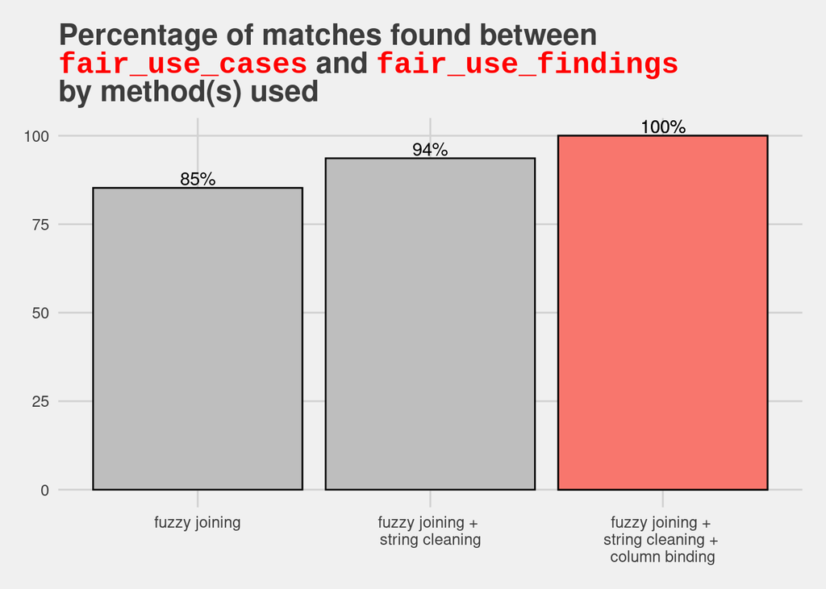

```r
data.frame("method" = c("fuzzy joining",
                        "fuzzy joining + \nstring cleaning",
                        "fuzzy joining + \nstring cleaning + \ncolumn binding"),
           "match_rate" = c((251-37)/251*100, (251-16)/251*100, 100),
           "class" = c(FALSE, FALSE, TRUE)) %>%
  ggplot(aes(x = method, y = match_rate, fill=class)) +
    geom_bar(stat="identity", colour="black") +
    geom_text(aes(label = paste0(round(match_rate), "%")), colour="black", vjust=-.2) +
    xlab("Method") +
    ylab("Match Rate") +
    ggtitle("Percentage of matches found between<br><span style='font-family:monospace;color:red'>fair_use_cases</span> and <span style='font-family:monospace;color:red'>fair_use_findings</span><br>by method(s) used") +
    ggthemes::theme_fivethirtyeight() +
    gghighlight::gghighlight(class == TRUE, unhighlighted_params = list(fill="grey", colour="black")) +
    theme(plot.title = ggtext::element_markdown(),
          plot.caption = ggtext::element_markdown())
```

```r
ggsave('social-image.png', height=5, width=10)
```